# Regras de associação para produtos

Gleynner Ghiotto

# 1 Entendendo o problema

No seguinte case temos uma base de dados com informações de compras de um supermercado, onde, a nossa tarefa é fazer uma análise descritiva e identificar a possibilidades deste mercado realizar vendas casadas de itens/produtos e marcas.

O primeiro conjunto de dados, de itens, nos fornece os códigos de cada item e suas respectivas descrições quanto ao produto, marca e tipo. O segundo conjunto, de transacões, contém o identificador de cada transação, com seu respectivo valor e forma de pagamento. No último conjunto de dados, de itens por transação, foi mostrado o identificador de cada transação e o conjunto de itens incluídos em cada uma delas.

Na tabela 01 são mostrados os produtos, marcas e o tipo (categoria) de produto que são vendidos nesse mercado.

**Tabela 01:** produtos, marcas e tipo de produtos vendidos.

| codItem | descricao | marca | tipo |
| --- | --- | --- | --- |
| 1 | banana prata | banana | fruta |
| 2 | banana caturra | banana | fruta |
| 3 | limao Taiti | limao | fruta |
| 4 | limão siciliano | limao | fruta |
| 5 | coca | coca | refrigerante |
| 6 | coca light | coca | refrigerante |
| 7 | coca lemon light | coca | refrigerante |
| 10 | omo collors | omo | sabao em po |
| 11 | omo progress | omo | sabao em po |
| 12 | ariel total | ariel | sabao em po |

Após observar os conjunto de dados individualmente, foi feito a união dessas bases, levando em consideração suas variáveis chaves, quantidade de linhas e a lógica de ligação entre elas. Desta forma, tivemos em apenas uma base de dados as informações das características de compra de cada cliente com o seu respectivo valor por transação e forma de pagamento. Na tabela 02, temos o quadro de dados com todas as informações de compra para cada transação.

**Tabela 02:** base de dados após união dos diferentes conjuntos.

| IDTransacao | item | descricao | marca | tipo | valorTotal | tipoPagamento |
| --- | --- | --- | --- | --- | --- | --- |
| 1 | 1 | banana prata | banana | fruta | 15 | ch |
| 1 | 4 | limão siciliano | limao | fruta | 15 | ch |
| 1 | 12 | ariel total | ariel | sabao em po | 15 | ch |
| 2 | 12 | ariel total | ariel | sabao em po | 20 | ch |
| 3 | 2 | banana caturra | banana | fruta | 14 | es |
| 3 | 12 | ariel total | ariel | sabao em po | 14 | es |
| 5 | 2 | banana caturra | banana | fruta | 15 | es |
| 5 | 5 | coca | coca | refrigerante | 15 | es |
| 6 | 1 | banana prata | banana | fruta | 24 | cc |
| 6 | 3 | limao Taiti | limao | fruta | 24 | cc |
| 6 | 12 | ariel total | ariel | sabao em po | 24 | cc |
| 14 | 1 | banana prata | banana | fruta | 10 | es |
| 14 | 3 | limao Taiti | limao | fruta | 10 | es |
| 14 | 6 | coca light | coca | refrigerante | 10 | es |
| 14 | 12 | ariel total | ariel | sabao em po | 10 | es |
| 15 | 1 | banana prata | banana | fruta | 20 | cc |
| 15 | 3 | limao Taiti | limao | fruta | 20 | cc |
| 15 | 6 | coca light | coca | refrigerante | 20 | cc |
| 15 | 11 | omo progress | omo | sabao em po | 20 | cc |
| 16 | 2 | banana caturra | banana | fruta | 11 | es |
| 16 | 4 | limão siciliano | limao | fruta | 11 | es |
| 16 | 6 | coca light | coca | refrigerante | 11 | es |
| 17 | 2 | banana caturra | banana | fruta | 21 | ch |
| 17 | 4 | limão siciliano | limao | fruta | 21 | ch |
| 17 | 6 | coca light | coca | refrigerante | 21 | ch |
| 17 | 11 | omo progress | omo | sabao em po | 21 | ch |
| 18 | 1 | banana prata | banana | fruta | 12 | es |
| 18 | 4 | limão siciliano | limao | fruta | 12 | es |
| 18 | 5 | coca | coca | refrigerante | 12 | es |
| 19 | 1 | banana prata | banana | fruta | 20 | ch |

[output cut: 55 more lines]

Na Figura 01 é mostrado a quantidade de produtos vendidos em cada transação. Observa-se que a quantidade máxima de itens por compra foi igual a 5 unidades e a mínima foi igual a 1, enquanto, a média de produtos por compra foi de 3.15 unidades.

**Figura 01:** Quantidade de itens vendidos em cada transação.

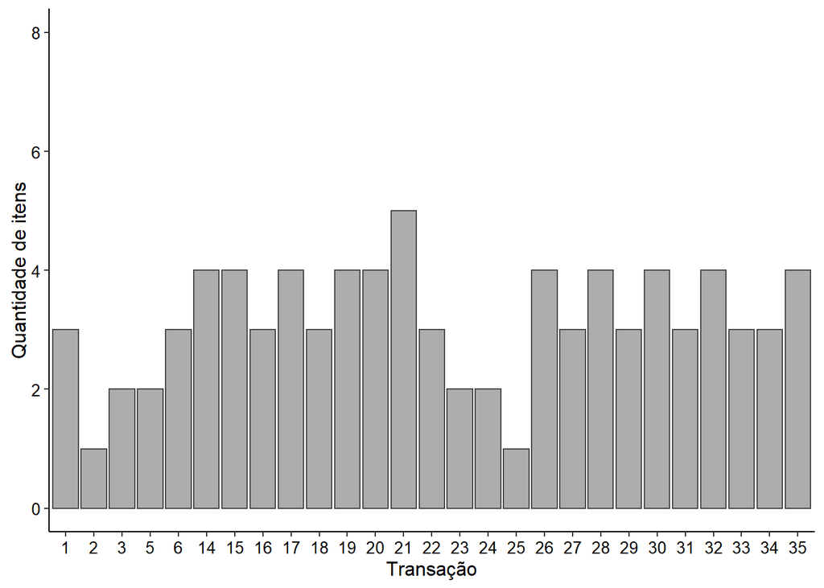

Na Figura 02 podemos observar a quantidade vendida de cada produto e, por meio da mesma, torna-se notável que os três produtos mais vendidos são: coca light, banana prata e banana caturra, respectivamente. Já os produtos que tem menos saída são: a coca, coca lemon light e omo progress.

**Figura 02:** Quantidade vendida de cada item.

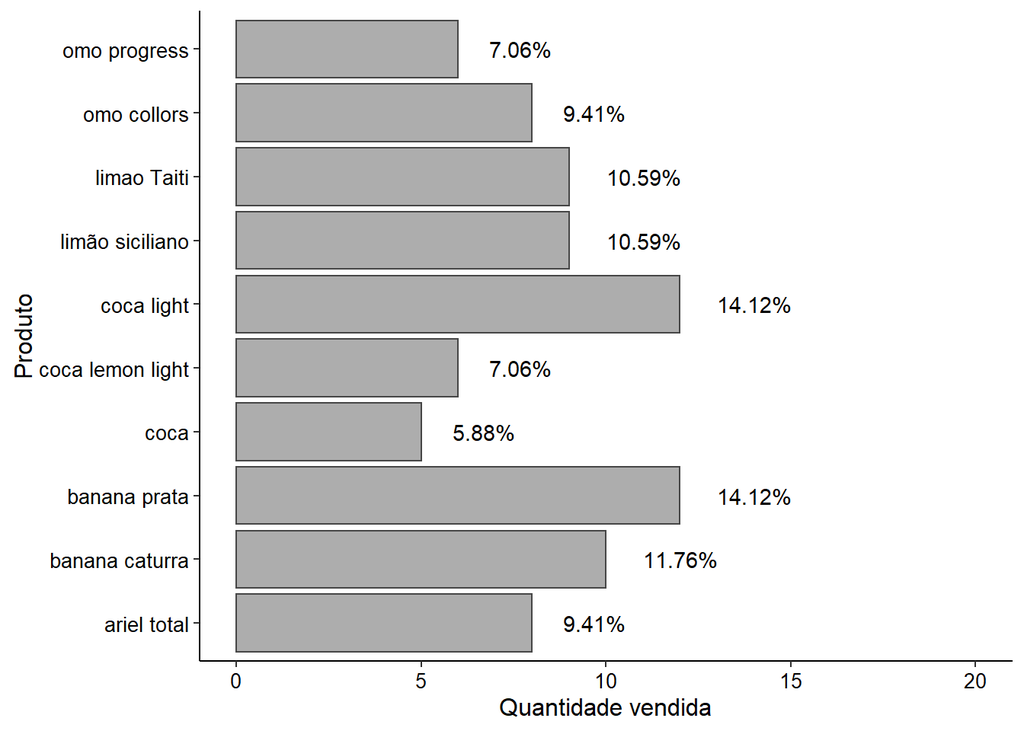

Os dez produtos vendidos nesse mercado são classificados em cinco diferentes marcas e três tipos de produtos. As marcas de produtos mais vendidas são a coca, banana e limão, respectivamente; dentre as categorias de produtos, as frutas é claramente o tipo que mais vende. Na figura 03 pode ser melhor observador a quantidade de vendas por marca e tipo.

**Figura 03:** Quantidade vendida por marca e tipo de produto.

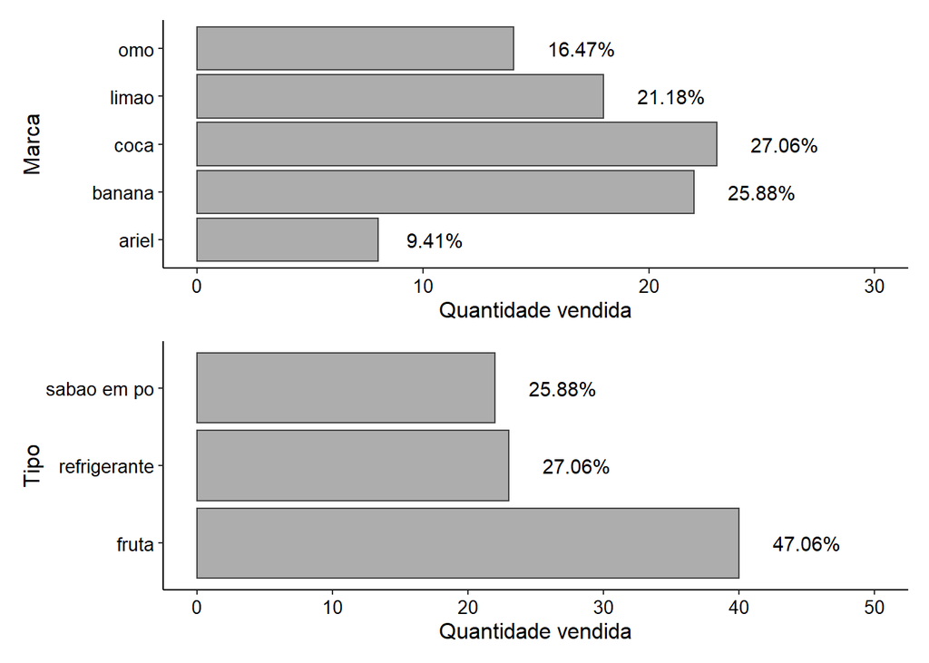

Também podemos ter uma visualização de forma simplificada do valor em reais de cada transação com o seu respectivo valor percentual, dado o valor total de compras. Por meio da figura 04, pode-se observar que os clientes com o ID 22 e 32 foram os que fizeram compras de maior valor e não necessariamente seriam os clientes que levaram a maior quantidade de produtos, de acordo com a figura 01.

**Figura 04:** Valor de cada transação.

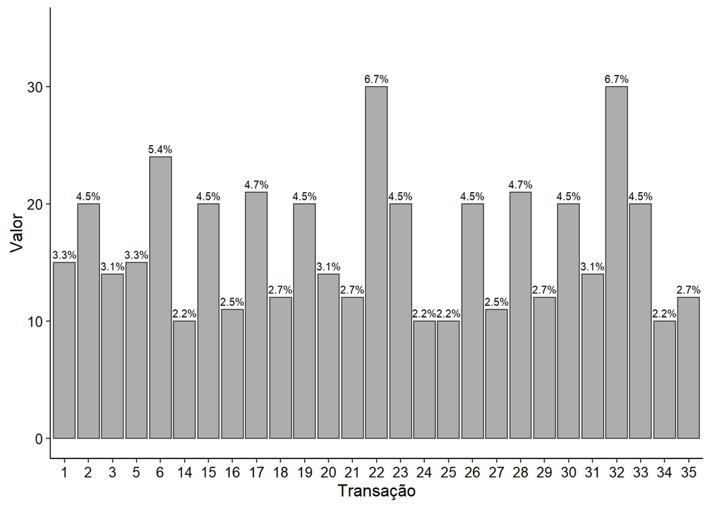

**Figura 05:** frequência para os tipos de pagamento.

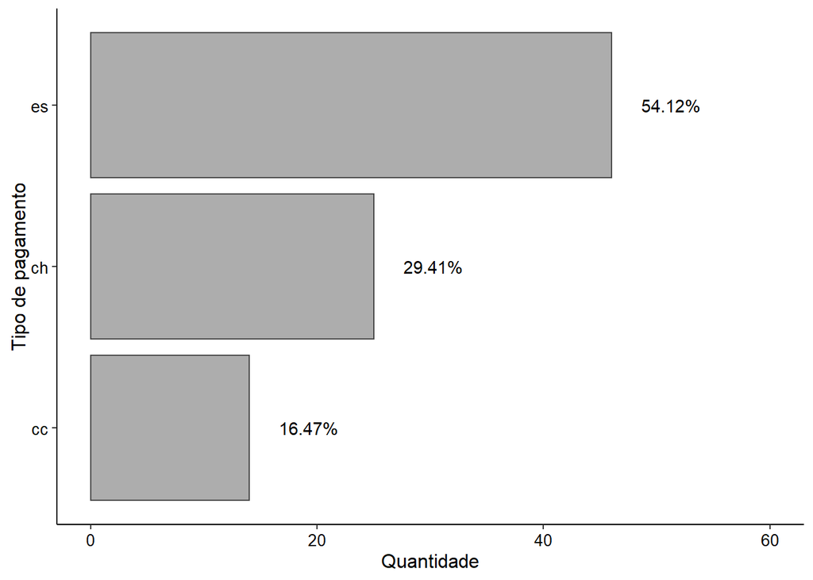

# 2 Gerar regras de associação

As regras de associação têm como premissa básica encontrar relacionamentos ou padrões frequentes no conjunto de dados.

Com esta finalidade, o **suporte** é usado para definir a proporção mínima de vezes que cada produto ou conjunto de produtos devem aparecer na base de dados, sendo o suporte mínimo definido pelo usuário. A **confiança** nos dá a probabilidade de se comprar um determinado produto ou combinação deles, lenvando-se em consideração a ordem da escolha, sendo a confiança mínima também definida pelo usuário. Já o **lift** nos fornece o grau de relevância de cada regra. O lift A -> B (SE A ENTAO B) indica o quão mais frequente se torna um produto B quando o item A ocorre. Ou seja, se o lift A -> B é igual a 2, isto indica que clientes que compram o **Produto A** têm 2 vezes mais chances de comprar o **Produto B**.

## 2.1 Regras de associação para produtos

Para gerar as regras de associação para os produtos definimos o suporte mínimo e o nível de confiança iguais a 10% e 75%, respectivamente. As regras geradas são apresentadas na tabela 03. Por meio dela pode-se observar que, quando um cliente compra coca light e limão taiti, a chance dele comprar omo progress é 3,37 vezes maior, com uma confiança de 75%. Já ao comprar banana caturra e coca light, tem-se 3 vezes mais chaces de se comprar limão siciliano, com uma confiança de 100%. A terceira regra é composta pelos mesmos produtos que a segunda regra, com ordem de escolha diferente, porém, isto fez com houvesse uma diminuição na relevância da terceira. Por fim, quando um cliente compra limão taiti e omo progress, ele tem 2,25 mais chance de também comprar coca light. Isto pode indicar que um determinado cliente gosta de beber coca light enquanto está lavando roupa.

**Tabela 03:** regras de associação para produtos.

| SE | ENTAO | Suporte | Confianca | Lift |
| --- | --- | --- | --- | --- |
| {coca light=1,limao Taiti=1} | {omo progress=1} | 11.11% | 75% | 3.3750 |
| {banana caturra=1,coca light=1} | {limão siciliano=1} | 14.81% | 100% | 3.0000 |
| {coca light=1,limão siciliano=1} | {banana caturra=1} | 14.81% | 100% | 2.7000 |
| {limao Taiti=1,omo progress=1} | {coca light=1} | 11.11% | 100% | 2.2500 |
| {banana caturra=1,limão siciliano=1} | {coca light=1} | 14.81% | 100% | 2.2500 |
| {omo progress=1} | {coca light=1} | 18.52% | 83.33% | 1.8750 |
| {banana prata=1,limao Taiti=1} | {coca light=1} | 11.11% | 75% | 1.6875 |
| {coca light=1,limao Taiti=1} | {banana prata=1} | 11.11% | 75% | 1.6875 |

## 2.2 Regras de associação de marcas

Para gerar as regras de associação para marcas, utilizamos um suporte igual a 30% e uma confiança de 80%. As regras geradas para as marcas tiveram um nível de relevância menor quando comparadas com as regras geradas para os produtos. Para exemplicar, uma pessoa que compra banana e coca, ela também costuma comprar limão. Outra regra é que, sempre que uma dona de casa vai comprar sabão em pó (omo) ela também compra coca. As demais regras geradas podem ser vistas na tabela 04.

**Tabela 04:** regras de associação para marcas.

| SE | ENTAO | Suporte | Confianca | Lift |
| --- | --- | --- | --- | --- |
| {banana=1,coca=1} | {limao=1} | 55.56% | 83.33% | 1.250000 |
| {omo=1} | {coca=1} | 51.85% | 100% | 1.227273 |
| {limao=1,omo=1} | {coca=1} | 33.33% | 100% | 1.227273 |
| {banana=1,omo=1} | {coca=1} | 37.04% | 100% | 1.227273 |
| {limao=1} | {banana=1} | 62.96% | 94.44% | 1.159091 |
| {coca=1,limao=1} | {banana=1} | 55.56% | 93.75% | 1.150568 |
| {limao=1} | {coca=1} | 59.26% | 88.89% | 1.090909 |
| {banana=1,limao=1} | {coca=1} | 55.56% | 88.24% | 1.082888 |
| {banana=1} | {coca=1} | 66.67% | 81.82% | 1.004132 |
| {coca=1} | {banana=1} | 66.67% | 81.82% | 1.004132 |